# oefeningen hoofdstuk 6 - Analyse op 2 Variabelen

TijsMartens

12 april 2019

# voorbeeld bij 6.2: Het opstellen van een kruistabel

data invoeren en opmaken van de tabel

```r
waarderingen_m <- matrix(c(9,8,5,0,8,10,5,4), ncol = 2)

rownames(waarderingen_m) <- c("Goed","Voldoende", "Onvoldoende", "Slecht")
colnames(waarderingen_m)<- c("Man", "Vrouw")
waarderingen <- as.table(waarderingen_m)
```

marginale totalen berekenen

```r
margin.table(waarderingen, 1) # rijtotalen
```

```
##        Goed   Voldoende Onvoldoende      Slecht
##          17          18          10           4
```

```r
margin.table(waarderingen, 2) # kolomtotalen
```

```
##   Man Vrouw
##    22    27
```

```r
margin.table(waarderingen) # aantal waarnemingen (n)
```

```
## [1] 49
```

```r
waarderingen_pct <- prop.table(waarderingen, 2)
waarderingen_pct
```

```
##                   Man     Vrouw
## Goed        0.4090909 0.2962963
## Voldoende   0.3636364 0.3703704
## Onvoldoende 0.2272727 0.1851852
## Slecht      0.0000000 0.1481481
```

berekenen chi-kwadraat

```r
#verwacht <- as.array(margin.table(waarderingen, 1)) %*%t(as.array(margin.table(waarderingen, 2))) / margin.#table(waarderingen)

#afwijking <- (waarderingen - verwacht) ^ 2 / verwacht

#sum(afwijking)

## ^ is het zelfde als volgende code


summ <- summary(waarderingen)
chi_sq <- summ$statistic

chi_sq
```

```
## [1] 3.810518
```

berekenen van Cramér’s V

```r
k <- min(nrow(waarderingen), ncol(waarderingen))
V <- sqrt(chi_sq/margin.table((waarderingen) * (k-1)))

k
```

```
## [1] 2
```

```r
V
```

```
## [1] 0.278865
```

bekomen resultaten

```r
t(waarderingen)
```

```
##       Goed Voldoende Onvoldoende Slecht
## Man      9         8           5      0
## Vrouw    8        10           5      4
```

```r
waarderingen
```

```
##             Man Vrouw
## Goed          9     8
## Voldoende     8    10
## Onvoldoende   5     5
## Slecht        0     4
```

```r
waarderingen_pct
```

```
##                   Man     Vrouw
## Goed        0.4090909 0.2962963
## Voldoende   0.3636364 0.3703704
## Onvoldoende 0.2272727 0.1851852
## Slecht      0.0000000 0.1481481
```

maken tabel

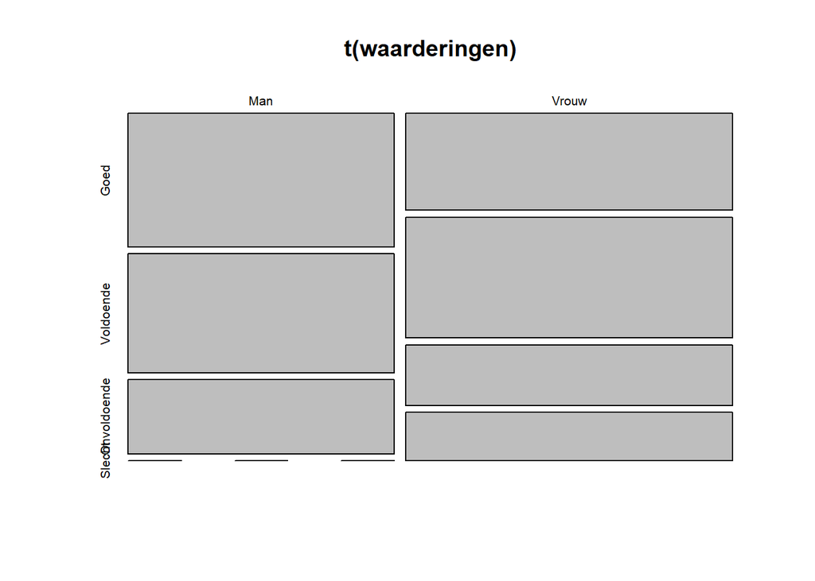

```r
plot(t(waarderingen))
```

maken geclustere bar chart

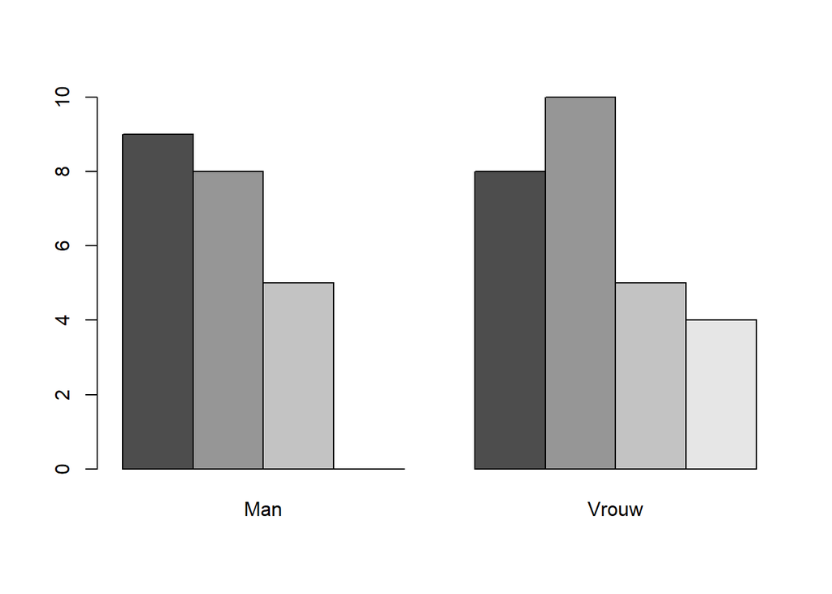

```r
barplot(waarderingen, beside = TRUE)
```

maken van percentage chart

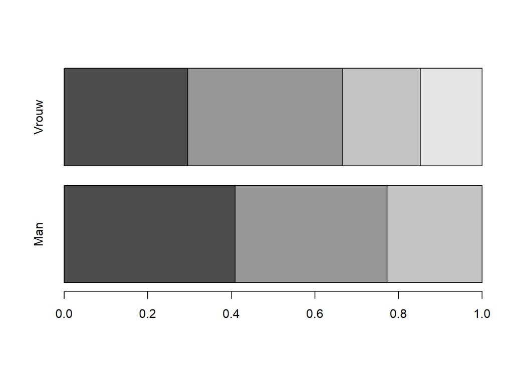

```r
barplot(waarderingen_pct, horiz = TRUE)
```

# voorbeeld 6.4.

voorbeelde van een regressierechte

```r
data <- read.csv("C:\\Users\\tijsm\\Google Drive\\HoGent 2018-2019\\2e semester\\Onderzoekstechnieken\\files\\onderzoekstechnieken-cursus\\cursus\\data\\santa.txt", sep=";", dec=",")

attach(data)
data
```

[output not shown]

code is juist om regressierechte te tekenen. Maar hij kent kolom “x” en “y” smh niet

```r
#x = eiwitgehalte
#y = gewichttoename

#plot(x, y, main = 'gewichttoename', xlab = 'eiwitgehalte', ylab = 'gewichtstoename')

##regressie berekenen

#regr <- lm(y ~ x)
#regr

#abline(regr, col="red")
```

# oefening 6.1.

*(oefening zelf gemaakt, geen oplossing)*

## opgave

Marktonderzoek toont aan dat achtergrondmuziek in een supermarkt invloed kan hebben op het aankoopgedrag van de klanten. In een onderzoek werden drie methoden met elkaar vergeleken: geen muziek, Franse chansons en Italiaanse hits. Telkens werd het aantal verkochte ???essen Franse, Italiaanse en andere wijnen geteld (Ryan, Northrop-Clewes, Knox & Thurnham, 1998). De onderzoeksdata bevindt zich in het csv-bestand MuziekWijn.

## oplossing

inlezezen csv bestand

```r
data <- read.csv("C:\\Users\\tijsm\\Google Drive\\HoGent 2018-2019\\2e semester\\Onderzoekstechnieken\\files\\onderzoekstechnieken-cursus\\oefeningen\\data\\hfst6_2variabelen\\MuziekWijn.csv")

data
```

| Muziek | Wijn |
| --- | --- |
| Geen | Franse |
| Franse | Franse |
| Franse | Italiaanse |
| Italiaanse | Andere |
| Italiaanse | Franse |
| Italiaanse | Andere |
| Geen | Franse |
| Geen | Andere |
| Geen | Franse |
| Geen | Italiaanse |

[output cut: 233 more lines]

## 1.

opstellen van de frequentietabel

```r
kruistabel <-table(data)
kruistabel
```

```
##             Wijn
## Muziek        Andere  Franse  Italiaanse
##   Franse          35      39           1
##   Geen            43      30          11
##   Italiaanse      35      30          19
```

## 2.

bepalen van de marginalen

```r
margin.table(kruistabel, 1)
```

```
## Muziek
##     Franse       Geen Italiaanse
##         75         84         84
```

```r
margin.table(kruistabel, 2)
```

```
## Wijn
##      Andere      Franse  Italiaanse
##         113          99          31
```

```r
prop.table(kruistabel)
```

```
##             Wijn
## Muziek            Andere      Franse  Italiaanse
##   Franse     0.144032922 0.160493827 0.004115226
##   Geen       0.176954733 0.123456790 0.045267490
##   Italiaanse 0.144032922 0.123456790 0.078189300
```

## 3.

bepalen van de verwachte waarden

```r
library(gmodels)
library(lsr)

CrossTable(kruistabel)
```

```
##
##
##    Cell Contents
## |-------------------------|
## |                       N |
## | Chi-square contribution |
## |           N / Row Total |
## |           N / Col Total |
## |         N / Table Total |
## |-------------------------|
##
##
## Total Observations in Table:  243
##
##
##              | Wijn
##       Muziek |      Andere |      Franse |  Italiaanse |   Row Total |
## -------------|-------------|-------------|-------------|-------------|
##       Franse |          35 |          39 |           1 |          75 |
##              |       0.000 |       2.334 |       7.672 |             |
##              |       0.467 |       0.520 |       0.013 |       0.309 |
##              |       0.310 |       0.394 |       0.032 |             |
##              |       0.144 |       0.160 |       0.004 |             |
## -------------|-------------|-------------|-------------|-------------|
##         Geen |          43 |          30 |          11 |          84 |
##              |       0.397 |       0.521 |       0.008 |             |
##              |       0.512 |       0.357 |       0.131 |       0.346 |
##              |       0.381 |       0.303 |       0.355 |             |
##              |       0.177 |       0.123 |       0.045 |             |
## -------------|-------------|-------------|-------------|-------------|
##   Italiaanse |          35 |          30 |          19 |          84 |
##              |       0.422 |       0.521 |       6.404 |             |
##              |       0.417 |       0.357 |       0.226 |       0.346 |
##              |       0.310 |       0.303 |       0.613 |             |
##              |       0.144 |       0.123 |       0.078 |             |
## -------------|-------------|-------------|-------------|-------------|
## Column Total |         113 |          99 |          31 |         243 |
##              |       0.465 |       0.407 |       0.128 |             |
## -------------|-------------|-------------|-------------|-------------|
##
##
```

## 4.

```r
cramersV(kruistabel)
```

```
## [1] 0.193937
```

manueel:

$\sum \frac{(a - e)^2}{e}$

a = geobserveerde waarde e = verwachte waarde

- verwachte waarde berekenen

$e = (\frac{rijtotaal}{n} \times \frac{kolomtotaal}{n} \times n)$ $e = \frac{rijtotaal \times kolomtotaal}{n}$

```r
kruistabel
```

```
##             Wijn
## Muziek        Andere  Franse  Italiaanse
##   Franse          35      39           1
##   Geen            43      30          11
##   Italiaanse      35      30          19
```

```r
aantalKol <- ncol(kruistabel)
aantalKol
```

```
## [1] 3
```

```r
aantalRij <- nrow(kruistabel)
aantalRij
```

```
## [1] 3
```

```r
n <- nrow(data)
n
```

```
## [1] 243
```

```r
e = (aantalKol * aantalRij) / n
e
```

```
## [1] 0.03703704
```

## 5.

```r
chisq.test(kruistabel)
```

```
##
##  Pearson's Chi-squared test
##
## data:  kruistabel
## X-squared = 18.279, df = 4, p-value = 0.001088
```

```r
qchisq(0.95, df = 4)
```

```
## [1] 9.487729
```

```r
qchisq(1-0.001088, df = 4)
```

```
## [1] 18.27978
```

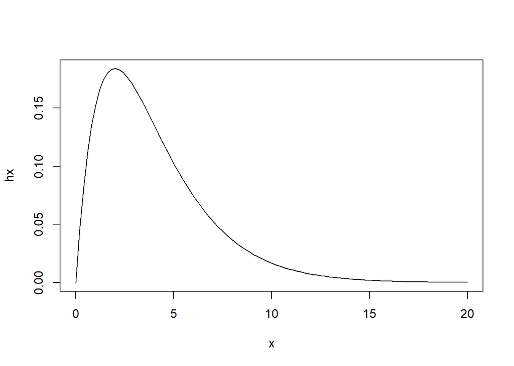

```r
x <- seq(0, 20, length=100)
hx <- dchisq(x, df = 4)
plot(x, hx, type="l")
```

# oefening 6.2.

*(oefening zelf gemaakt, geen oplossing)*

## opgave

Gebruik dezelfde data.

1. Stel de percentages verkochte wijnen voor in een staafdiagram met de muziekconditie= Geen.
2. Stel de percentages verkochte wijnen voor in een geclusterd staafdiagram (clustered bar chart).
3. Stel de percentages verkochte wijnen voor in rependiagram (stacked bar chart) ## oplossing

library(vcd) assocstats(data)

```r
data <- read.csv("C:\\Users\\tijsm\\Google Drive\\HoGent 2018-2019\\2e semester\\Onderzoekstechnieken\\files\\onderzoekstechnieken-cursus\\oefeningen\\data\\hfst6_2variabelen\\MuziekWijn.csv")

data
```

| Muziek | Wijn |
| --- | --- |
| Geen | Franse |
| Franse | Franse |
| Franse | Italiaanse |
| Italiaanse | Andere |
| Italiaanse | Franse |
| Italiaanse | Andere |
| Geen | Franse |
| Geen | Andere |
| Geen | Franse |
| Geen | Italiaanse |

[output cut: 233 more lines]

### 1. staafdiagram

```r
tabel <- table(data$Muziek)
tabel
```

```
##
##     Franse       Geen Italiaanse
##         75         84         84
```

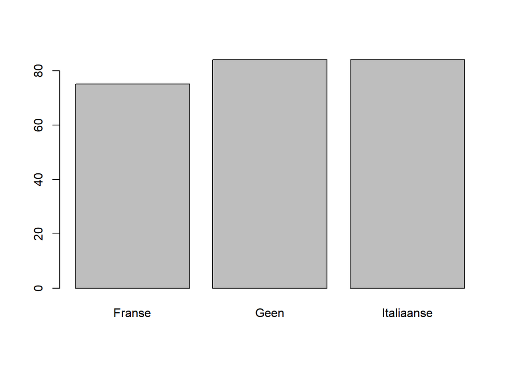

```r
barplot(tabel)
```

### 2. geclusterde staafdiagram

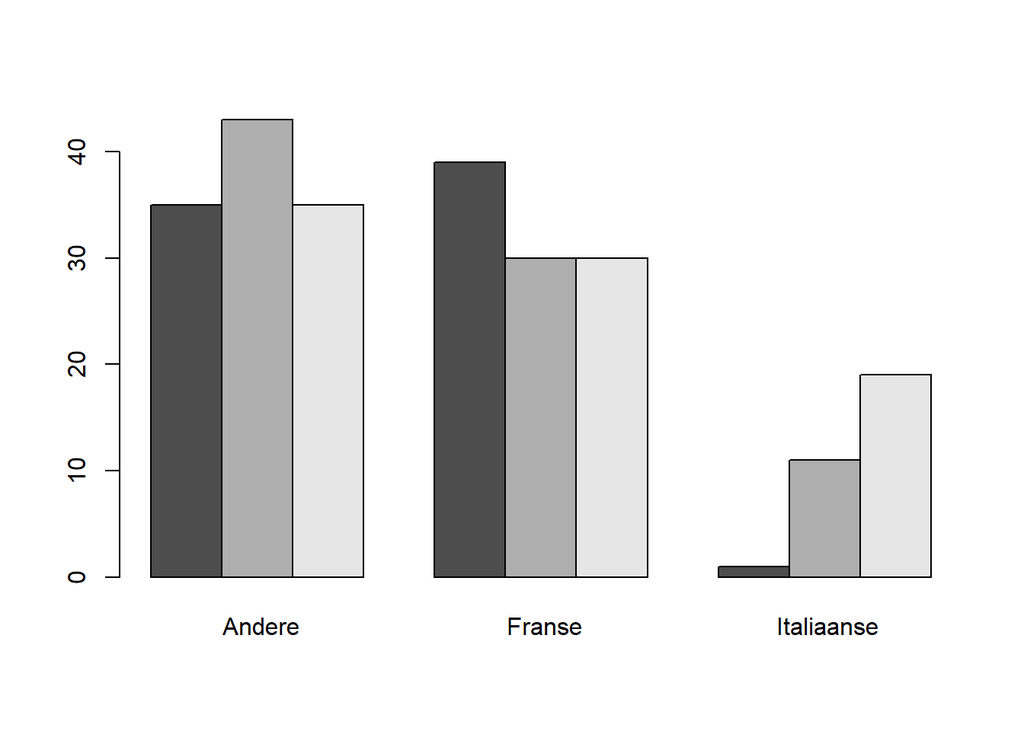

```r
tabel <- table(data)
barplot(tabel, beside = TRUE)
```

### 3. rependiagram - stacked bar chart

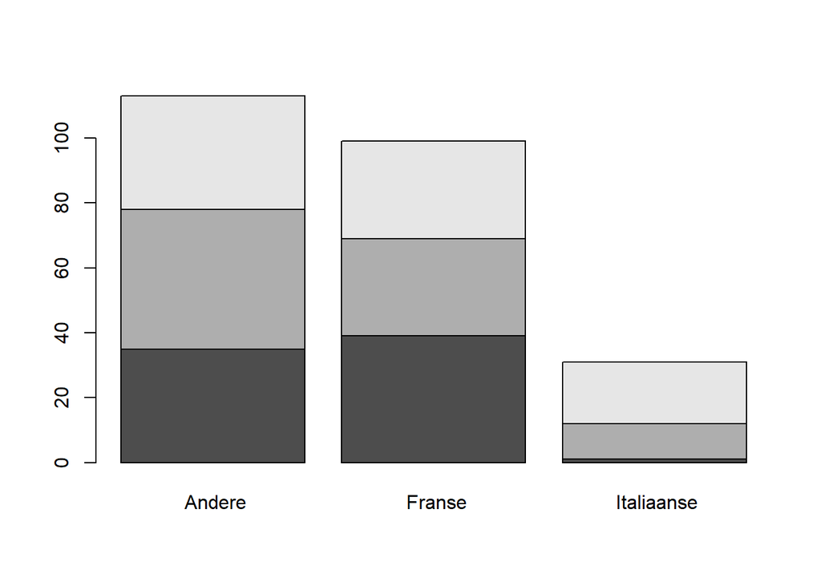

```r
tabel <- table(data)
barplot(tabel)
```

# oefening 6.3.

*(oefening zelf gemaakt, geen oplossing)*

## opgave

Lees het databestand “Aardbevingen.csv” in.

1. Maak een histogram en een boxplot van de variabele “Magnitudes”.
2. Maak een lijngra???ek met het aantal aardbevingen per maand.
3. Onderzoek of er een verband bestaat tussen de variabelen “Type” en “Source”. Bereken ook de Cramér’s V-waarde. Wat is de conclusie?

## oplossing

inlezen data

```r
aardbevingen <- read.csv("C:\\Users\\tijsm\\Google Drive\\HoGent 2018-2019\\2e semester\\Onderzoekstechnieken\\files\\onderzoekstechnieken-cursus\\oefeningen\\data\\hfst6_2variabelen\\Aardbevingen.csv")

View(aardbevingen)
```

### histogram van “magnitudes”

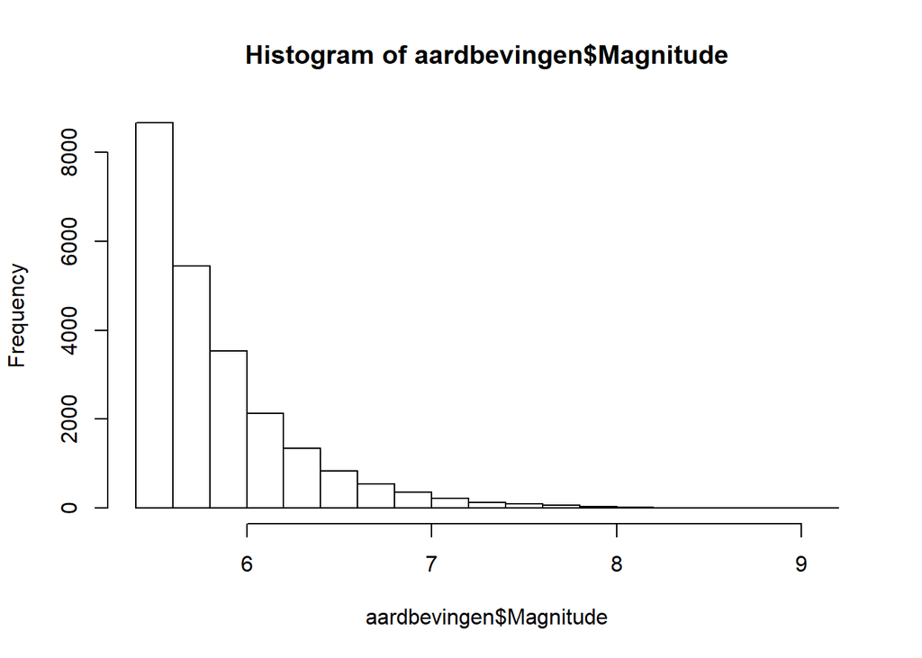

```r
hist(aardbevingen$Magnitude)
```

### boxplot van magnitudes

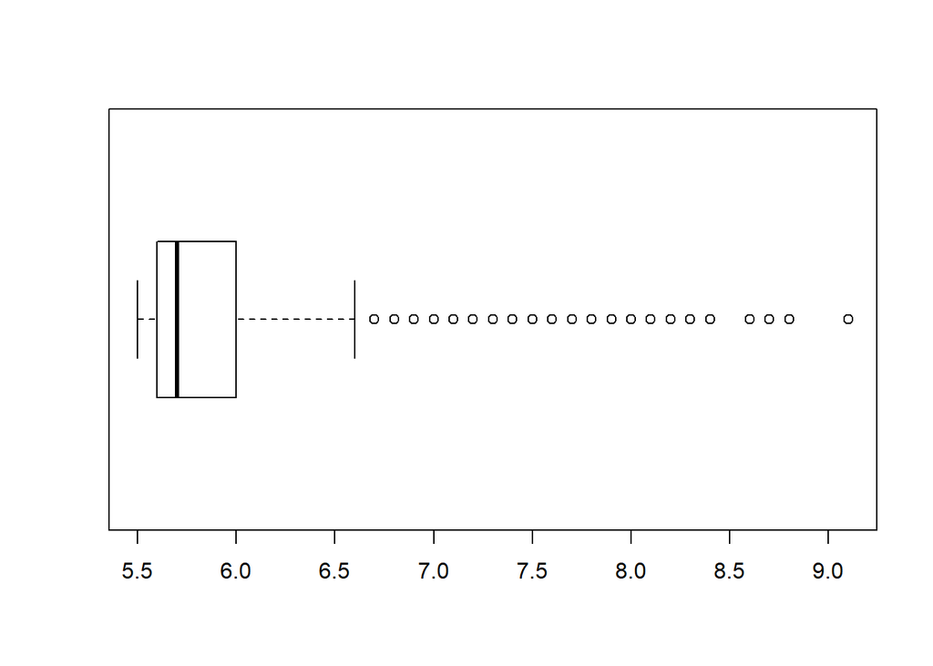

```r
boxplot(aardbevingen$Magnitude, horizontal = TRUE)
```

```r
typeof(aardbevingen$Date)
```

```
## [1] "integer"
```

```r
# omzetten integer naar data

aardbevingen$Date <- as.Date(aardbevingen$Date,"%Y/%m/%d")

typeof(aardbevingen$Date)
```

```
## [1] "double"
```

```r
str(aardbevingen)
```

```
## 'data.frame':    23412 obs. of  21 variables:
##  $ Date                      : Date, format: "0001-02-19" "0001-04-19" ...
##  $ Time                      : Factor w/ 20470 levels "00:00:03","00:00:04",..: 11786 9867 15449 16089 11613 11667 11605 19886 9902 9196 ...
##  $ Latitude                  : num  19.25 1.86 -20.58 -59.08 11.94 ...
##  $ Longitude                 : num  145.6 127.4 -174 -23.6 126.4 ...
##  $ Type                      : Factor w/ 4 levels "Earthquake","Explosion",..: 1 1 1 1 1 1 1 1 1 1 ...
##  $ Depth                     : num  132 80 20 15 15 ...
##  $ Depth.Error               : num  NA NA NA NA NA NA NA NA NA NA ...
##  $ Depth.Seismic.Stations    : int  NA NA NA NA NA NA NA NA NA NA ...
##  $ Magnitude                 : num  6 5.8 6.2 5.8 5.8 6.7 5.9 6 6 5.8 ...
##  $ Magnitude.Type            : Factor w/ 11 levels "","MB","MD","MH",..: 7 7 7 7 7 7 7 7 7 7 ...
##  $ Magnitude.Error           : num  NA NA NA NA NA NA NA NA NA NA ...
##  $ Magnitude.Seismic.Stations: int  NA NA NA NA NA NA NA NA NA NA ...
##  $ Azimuthal.Gap             : num  NA NA NA NA NA NA NA NA NA NA ...
##  $ Horizontal.Distance       : num  NA NA NA NA NA NA NA NA NA NA ...
##  $ Horizontal.Error          : num  NA NA NA NA NA NA NA NA NA NA ...
##  $ Root.Mean.Square          : num  NA NA NA NA NA NA NA NA NA NA ...
##  $ ID                        : Factor w/ 23412 levels "AK11232962","AK11248623",..: 2580 2581 2582 2583 2584 2585 2586 2587 2711 2588 ...
##  $ Source                    : Factor w/ 13 levels "AK","ATLAS","CI",..: 5 5 5 5 5 5 5 5 6 5 ...
##  $ Location.Source           : Factor w/ 48 levels "AEI","AEIC","AG",..: 21 21 21 21 21 21 21 21 21 21 ...
##  $ Magnitude.Source          : Factor w/ 24 levels "1000","1009",..: 12 12 12 12 12 12 12 12 12 12 ...
##  $ Status                    : Factor w/ 2 levels "Automatic","Reviewed": 1 1 1 1 1 1 1 1 1 1 ...
```

```r
aardbevingen$month <- as.Date(cut(aardbevingen$Date, breaks = "month"))


#??????????????????????????
```

[output not shown]

### onderzoek als er een verband is tussen “type” en “source”

*hypothese* h0 - er is geen verband h1 - er is wel een verband

*cramèrs v*

```r
cramersV(aardbevingen$Type, aardbevingen$Source)
```

```
## [1] 0.06709128
```

de cramèrs V is 0.067

een cramèrs v van 0 wil zeggen dat er geen verband is tussen da veriabelen een cramèrs v van 1 wil zeggen dat er een perfect vand is tussen de variaelen

In dit geval kunnen we dus stellen dat er geen verband is tussen het type en de oorzaak. We kunnne de nulhypothese dan ook NIET verwerpen

# oefening 6.4.

*(oefening zelf gemaakt, geen oplossing)*

## 1. handmatig

```r
x <- c(10, 12, 8, 13, 9, 10, 7, 14, 11, 6)
y <- c(11, 14, 9, 13, 9, 9, 8, 14, 10, 6)

mx <- mean(x)
my <- mean(y)

xx <- x - mx
yy <- y - my
beta1 <- sum(xx*yy)/sum(xx^2)
beta0 <- my - beta1 * mx
```

## 2.

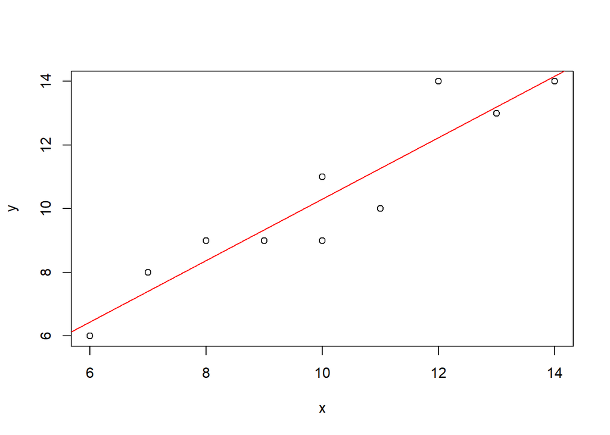

```r
plot(x, y)

regr <- lm(y~ x)
abline(regr, col="red")
```

## 3. uitleg

hoe dichter de punten bij de lijn ligt hoe beter het verband

## 4. bepaal handmatig r en r kwadraat

bepalen r

```r
cov(x = x, y = y)
```

```
## [1] 6.444444
```

pearson’s correlatie co

```r
rr <- cor (x, y)
rr
```

```
## [1] 0.9352406
```

# oefening 6.5.

/

*(oefening zelf gemaakt, geen oplossing)*

## oplossing

als r

- = 0 ==> geen verband te zien
- = 1 ==> stijgend verband
- = -1 ==> dalend verband

- 0.6
- de algemene trend van de waarden is stijgend, r moet dus groter zijn dan 0
- liggen niet heel dicht gegroepeerd, r dus ook nie “dicht” bij 1

r2 = D

r3 = C

- -0.9
- negatieve waarde = dalend verband
- dicht bij -1 dus de waarden moeten dicht bij elkaar liggen

r4 = A

- 0.9
- positieve waarde = stijgend verband
- dicht bij 1 dus de waarden moeten dicht bij elkaar liggen

r5 = F

# oefening 6.6.

*(oefening zelf gemaakt, geen oplossing)*

## opgave

Lees het databestand “Cats.csv” in. 1. Voer een lineaire regressieanalyse uit op de variabelen Lichaamsgewicht (Bwt, afhankelijke variabele) en Gewicht hart (Hwt, onafhankelijke variabele). 2. Maak een spreidingsdiagram van beide variabelen. 3. Bereken en teken de regressielijn. 4. Bereken de correlatie- en de determinatiecoëf???ciënt. 5. Geef een interpretatie van deze resultaten.

## oplossing

bestand inladen

```r
cats <- read.csv("C:\\Users\\tijsm\\Google Drive\\HoGent 2018-2019\\2e semester\\Onderzoekstechnieken\\files\\onderzoekstechnieken-cursus\\oefeningen\\data\\hfst6_2variabelen\\Cats.csv")
View(cats)
```

### 1. lineaire regressie

```r
afhankelijk <- cats$Bwt
onafhankelijk <- cats$Hwt

regr <- lm(onafhankelijk ~ afhankelijk)
regr
```

```
##
## Call:
## lm(formula = onafhankelijk ~ afhankelijk)
##
## Coefficients:
## (Intercept)  afhankelijk
##      1.0187       0.1604
```

### 2. spreidingsdiagram

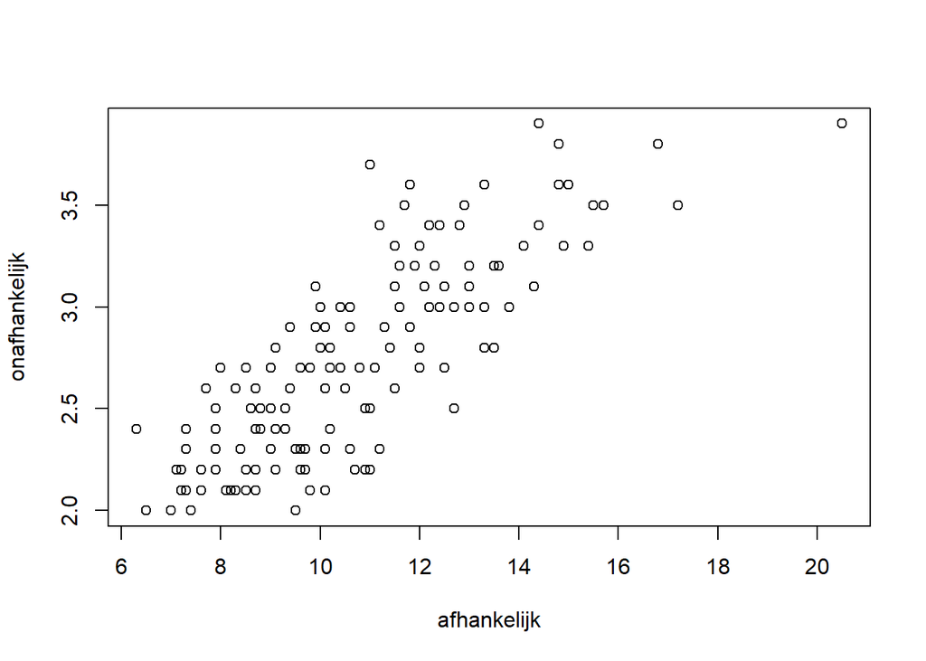

```r
plot(afhankelijk, onafhankelijk)
```

### 3. regressierechte

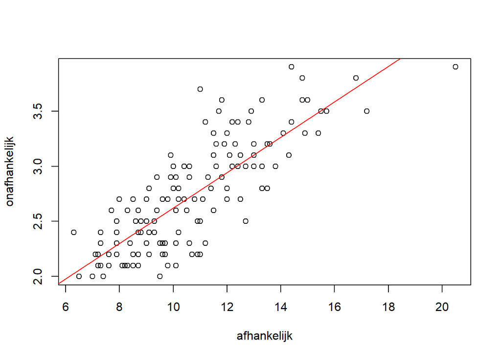

```r
plot(afhankelijk, onafhankelijk)

abline(regr, col="red")
```

### 4. correlatie en determinantcoëfficient

*manueel:*

```r
covarantie<-cov(onafhankelijk, afhankelijk)
covarantie
```

```
## [1] 0.9495697
```

```r
r = covarantie / (sd(onafhankelijk) * sd(afhankelijk))
correlatie <- r
correlatie
```

```
## [1] 0.8041348
```

```r
determinantcoefficient <- r*r
determinantcoefficient
```

```
## [1] 0.6466328
```

*met r:*

```r
co <- cor(onafhankelijk,afhankelijk, method = 'pearson')
co
```

```
## [1] 0.8041348
```

```r
determinantcoefficient <-co * co
determinantcoefficient
```

```
## [1] 0.6466328
```

### 5. interpretatie

er is een correlatie van 0.80. Dit duidt op een start stijgend verband.

de spreiding rond de regressierechte is vrij groot

# oefening 6.7.

## opgave

1. VoereenlineaireregressieanalyseuitopdevariabelenLichaamsgewicht(Bwt)enGewicht hart (Hwt) per geslacht.
2. Maak een spreidingsdiagram van beide variabelen voor elk van de geslachten.
3. Bereken en teken telkens de regressielijn.
4. Bereken de correlatie- en de determinatiecoëf???ciënt.
5. Geef een interpretatie aan deze resultaten.

## oplossing

bestand inladen

```r
cats <- read.csv("C:\\Users\\tijsm\\Google Drive\\HoGent 2018-2019\\2e semester\\Onderzoekstechnieken\\files\\onderzoekstechnieken-cursus\\oefeningen\\data\\hfst6_2variabelen\\Cats.csv")
View(cats)
```

### 1. regressie

```r
maleCats <- subset(cats, cats$Sex=="M")
femaleCats <- subset(cats, cats$Sex=="F")

#hangt gewicht van een hart of van het lichaamsgewicht?
maleAfhankelijk <- maleCats$Bwt
maleOnafhankelijk <- maleCats$Hwt

maleRegressie <- lm(maleOnafhankelijk ~ maleAfhankelijk)
maleRegressie
```

```
##
## Call:
## lm(formula = maleOnafhankelijk ~ maleAfhankelijk)
##
## Coefficients:
##     (Intercept)  maleAfhankelijk
##          1.2479           0.1459
```

```r
femaleAfhankelijk <- femaleCats$Bwt
femaleOnafhankelijk <- femaleCats$Hwt

femaleRegressie <- lm(femaleOnafhankelijk ~ femaleAfhankelijk)
femaleRegressie
```

```
##
## Call:
## lm(formula = femaleOnafhankelijk ~ femaleAfhankelijk)
##
## Coefficients:
##       (Intercept)  femaleAfhankelijk
##            1.3715             0.1074
```

### 2. spreiding

male:

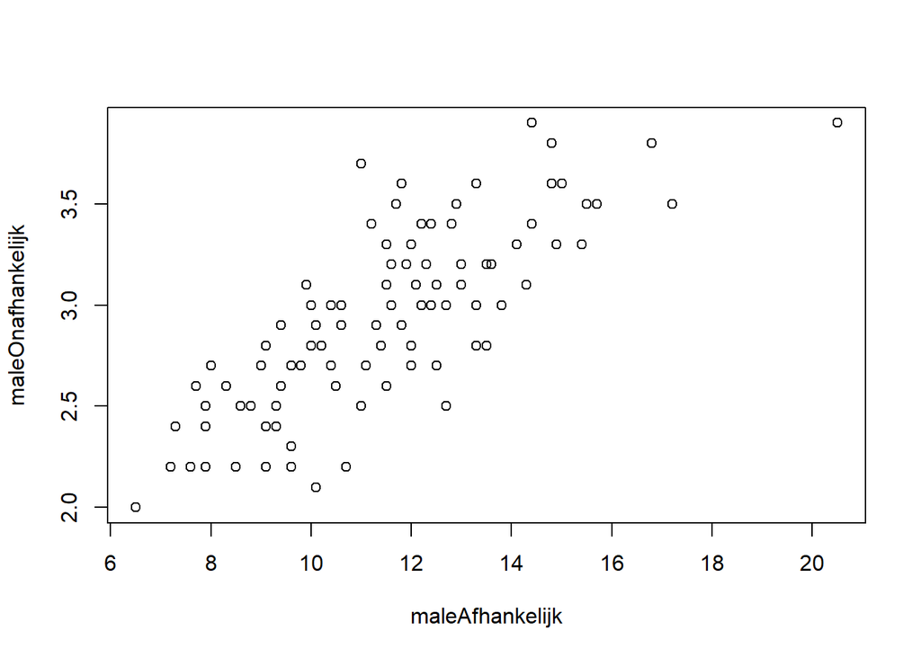

```r
plot(maleAfhankelijk, maleOnafhankelijk)
```

female

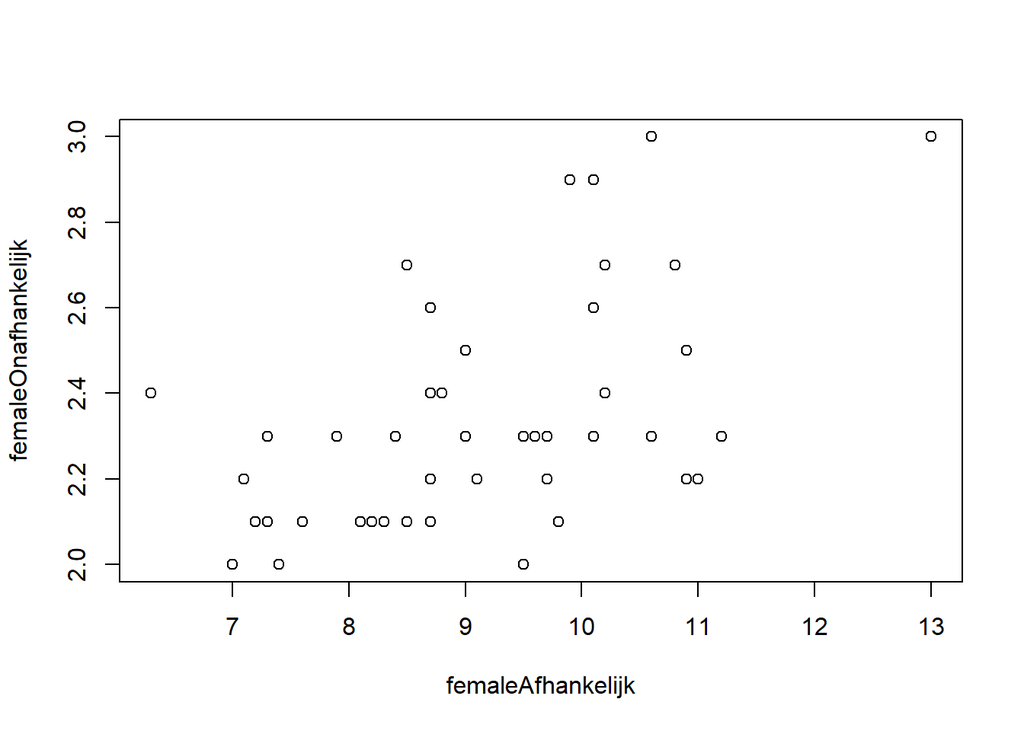

```r
plot(femaleAfhankelijk, femaleOnafhankelijk)
```

### 3. regressierechte

male:

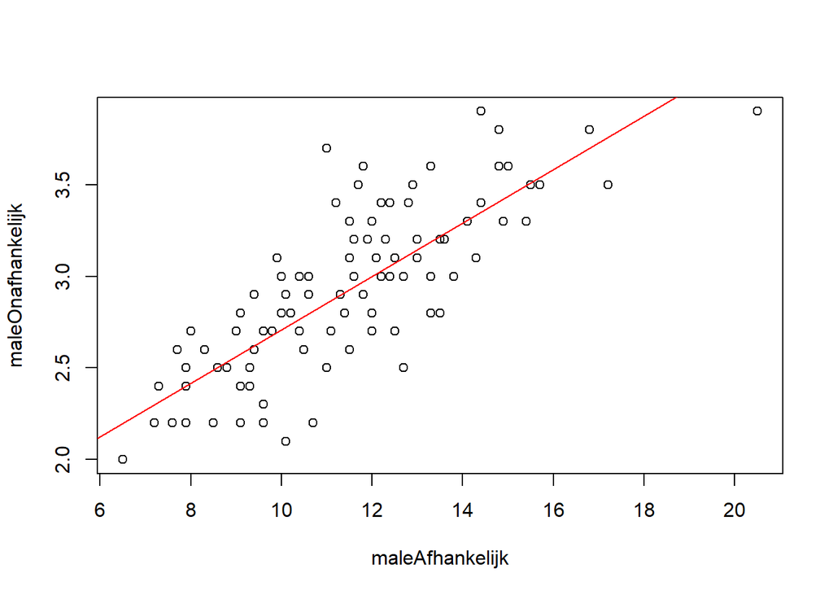

```r
plot(maleAfhankelijk, maleOnafhankelijk)
abline(maleRegressie, col = "red")
```

female:

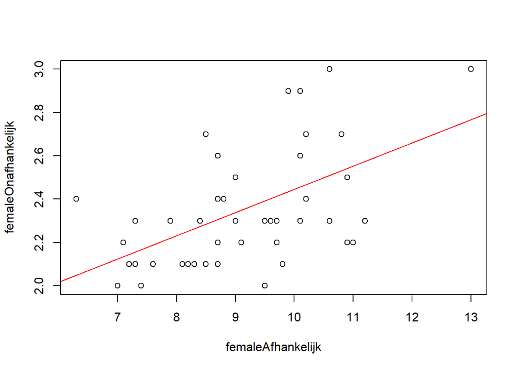

```r
plot(femaleAfhankelijk, femaleOnafhankelijk)
abline(femaleRegressie, col = "red")
```

### 4. correlatie en determinantcoefficient

male

```r
maleCo <- cor(maleOnafhankelijk,maleAfhankelijk, method = 'pearson')
maleCo
```

```
## [1] 0.7930443
```

```r
maleDeterminantcoefficient <-maleCo * maleCo
maleDeterminantcoefficient
```

```
## [1] 0.6289193
```

female

```r
femaleCo <- cor(femaleOnafhankelijk,femaleAfhankelijk, method = 'pearson')
femaleCo
```

```
## [1] 0.5320497
```

```r
femaleDeterminantcoefficient <-femaleCo * femaleCo
femaleDeterminantcoefficient
```

```
## [1] 0.2830768
```

### 5. interpretatie

male

- sterk sijgend lineair verband

female

- zwak stijgend lineair verband

# oefening 6.8.

*(oefening zelf gemaakt, geen oplossing)*

## opgave

Lees het databestand “Pizza.csv” in.

1. Voer een volledige lineaire regressieanalyse uit op de variabelen Rating en CostPerSlice. Trek hieruit de juiste conclusies en ga deze ook gra???sch na.
2. Onderzoek een mogelijk verband tussen Rating en Neighbourhood. Welke methode kan je hiervoorgebruiken? KanjedegegevensvanRatinghiervoorindezelfdevormgebruiken?
3. Geef een interpretatie aan deze resultaten.
4. Stel de kruistabel gra???sch voor met een staafdiagram. Voorzie een legende.

## oplossing

inlezen data

```r
pizzas <- read.csv("C:\\Users\\tijsm\\Google Drive\\HoGent 2018-2019\\2e semester\\Onderzoekstechnieken\\files\\onderzoekstechnieken-cursus\\oefeningen\\data\\hfst6_2variabelen\\Pizza.csv")
View(pizzas)
```

### 1. regressie

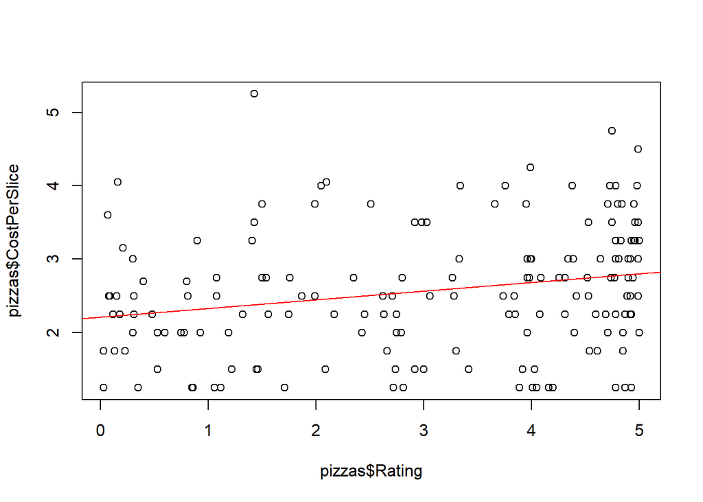

```r
plot(pizzas$Rating, pizzas$CostPerSlice)

regr <- lm(pizzas$CostPerSlice ~ pizzas$Rating)
abline(regr, col='red')
```

```r
regr
```

```
##
## Call:
## lm(formula = pizzas$CostPerSlice ~ pizzas$Rating)
##
## Coefficients:
##   (Intercept)  pizzas$Rating
##        2.2107         0.1183
```

er is weinig samenhang

### 2. relatie tussen rating en neigbourhood